# Risk Factor Analysis

## Outcome Variable

**Outcome Variable:** ever_stunted

## Predictor Variables

**Intervention Variable:** birthwt

**Adjustment Set:**

- arm
- sex
- W_mage
- meducyrs
- feducyrs
- W_mhtcm
- vagbrth
- single
- brthmon
- W_parity
- delta_W_mage
- delta_meducyrs
- delta_feducyrs
- delta_W_mhtcm
- delta_vagbrth
- delta_single
- delta_brthmon
- delta_W_parity

## Stratifying Variables

The analysis was stratified on these variable(s):

- agecat
- studyid
- country

## Data Summary

| agecat | studyid | country | birthwt | ever_stunted | n_cell | n |
| --- | --- | --- | --- | --- | --- | --- |
| 0-6 months | ki0047075b-MAL-ED | BANGLADESH | >=0 | 0 | 34 | 258 |
| 0-6 months | ki0047075b-MAL-ED | BANGLADESH | >=0 | 1 | 0 | 258 |
| 0-6 months | ki0047075b-MAL-ED | BANGLADESH | <-3 | 0 | 0 | 258 |
| 0-6 months | ki0047075b-MAL-ED | BANGLADESH | <-3 | 1 | 7 | 258 |
| 0-6 months | ki0047075b-MAL-ED | BANGLADESH | [-3–2) | 0 | 16 | 258 |
| 0-6 months | ki0047075b-MAL-ED | BANGLADESH | [-3–2) | 1 | 22 | 258 |
| 0-6 months | ki0047075b-MAL-ED | BANGLADESH | [-2–1) | 0 | 82 | 258 |
| 0-6 months | ki0047075b-MAL-ED | BANGLADESH | [-2–1) | 1 | 14 | 258 |
| 0-6 months | ki0047075b-MAL-ED | BANGLADESH | [-1-0) | 0 | 79 | 258 |
| 0-6 months | ki0047075b-MAL-ED | BANGLADESH | [-1-0) | 1 | 4 | 258 |
| 0-6 months | ki0047075b-MAL-ED | BRAZIL | >=0 | 0 | 123 | 233 |
| 0-6 months | ki0047075b-MAL-ED | BRAZIL | >=0 | 1 | 5 | 233 |
| 0-6 months | ki0047075b-MAL-ED | BRAZIL | [-3–2) | 0 | 2 | 233 |
| 0-6 months | ki0047075b-MAL-ED | BRAZIL | [-3–2) | 1 | 7 | 233 |
| 0-6 months | ki0047075b-MAL-ED | BRAZIL | [-2–1) | 0 | 16 | 233 |
| 0-6 months | ki0047075b-MAL-ED | BRAZIL | [-2–1) | 1 | 7 | 233 |
| 0-6 months | ki0047075b-MAL-ED | BRAZIL | [-1-0) | 0 | 67 | 233 |
| 0-6 months | ki0047075b-MAL-ED | BRAZIL | [-1-0) | 1 | 6 | 233 |
| 0-6 months | ki0047075b-MAL-ED | INDIA | >=0 | 0 | 44 | 245 |
| 0-6 months | ki0047075b-MAL-ED | INDIA | >=0 | 1 | 0 | 245 |
| 0-6 months | ki0047075b-MAL-ED | INDIA | <-3 | 0 | 0 | 245 |
| 0-6 months | ki0047075b-MAL-ED | INDIA | <-3 | 1 | 5 | 245 |
| 0-6 months | ki0047075b-MAL-ED | INDIA | [-3–2) | 0 | 12 | 245 |
| 0-6 months | ki0047075b-MAL-ED | INDIA | [-3–2) | 1 | 12 | 245 |
| 0-6 months | ki0047075b-MAL-ED | INDIA | [-2–1) | 0 | 62 | 245 |
| 0-6 months | ki0047075b-MAL-ED | INDIA | [-2–1) | 1 | 19 | 245 |
| 0-6 months | ki0047075b-MAL-ED | INDIA | [-1-0) | 0 | 86 | 245 |
| 0-6 months | ki0047075b-MAL-ED | INDIA | [-1-0) | 1 | 5 | 245 |
| 0-6 months | ki0047075b-MAL-ED | NEPAL | >=0 | 0 | 48 | 233 |
| 0-6 months | ki0047075b-MAL-ED | NEPAL | >=0 | 1 | 0 | 233 |

[output cut: 708 more lines]

The following strata were considered:

- agecat: 0-24 months, studyid: ki0047075b-MAL-ED, country: BANGLADESH
- agecat: 0-24 months, studyid: ki0047075b-MAL-ED, country: BRAZIL
- agecat: 0-24 months, studyid: ki0047075b-MAL-ED, country: INDIA
- agecat: 0-24 months, studyid: ki0047075b-MAL-ED, country: NEPAL
- agecat: 0-24 months, studyid: ki0047075b-MAL-ED, country: PERU
- agecat: 0-24 months, studyid: ki0047075b-MAL-ED, country: SOUTH AFRICA
- agecat: 0-24 months, studyid: ki0047075b-MAL-ED, country: TANZANIA, UNITED REPUBLIC OF
- agecat: 0-24 months, studyid: ki1000108-CMC-V-BCS-2002, country: INDIA
- agecat: 0-24 months, studyid: ki1000108-IRC, country: INDIA
- agecat: 0-24 months, studyid: ki1000109-EE, country: PAKISTAN
- agecat: 0-24 months, studyid: ki1000109-ResPak, country: PAKISTAN
- agecat: 0-24 months, studyid: ki1000304b-SAS-CompFeed, country: INDIA
- agecat: 0-24 months, studyid: ki1017093-NIH-Birth, country: BANGLADESH
- agecat: 0-24 months, studyid: ki1017093b-PROVIDE, country: BANGLADESH
- agecat: 0-24 months, studyid: ki1017093c-NIH-Crypto, country: BANGLADESH
- agecat: 0-24 months, studyid: ki1066203-TanzaniaChild2, country: TANZANIA, UNITED REPUBLIC OF
- agecat: 0-24 months, studyid: ki1101329-Keneba, country: GAMBIA
- agecat: 0-24 months, studyid: ki1114097-CMIN, country: BANGLADESH
- agecat: 0-24 months, studyid: ki1114097-CMIN, country: BRAZIL
- agecat: 0-24 months, studyid: ki1114097-CMIN, country: PERU
- agecat: 0-24 months, studyid: ki1114097-CONTENT, country: PERU
- agecat: 0-24 months, studyid: ki1119695-PROBIT, country: BELARUS
- agecat: 0-24 months, studyid: ki1126311-ZVITAMBO, country: ZIMBABWE
- agecat: 0-24 months, studyid: ki1135781-COHORTS, country: GUATEMALA
- agecat: 0-24 months, studyid: ki1135781-COHORTS, country: INDIA
- agecat: 0-24 months, studyid: ki1135781-COHORTS, country: PHILIPPINES
- agecat: 0-24 months, studyid: kiGH5241-JiVitA-3, country: BANGLADESH
- agecat: 0-24 months, studyid: kiGH5241-JiVitA-4, country: BANGLADESH
- agecat: 0-6 months, studyid: ki0047075b-MAL-ED, country: BANGLADESH
- agecat: 0-6 months, studyid: ki0047075b-MAL-ED, country: BRAZIL
- agecat: 0-6 months, studyid: ki0047075b-MAL-ED, country: INDIA
- agecat: 0-6 months, studyid: ki0047075b-MAL-ED, country: NEPAL
- agecat: 0-6 months, studyid: ki0047075b-MAL-ED, country: PERU
- agecat: 0-6 months, studyid: ki0047075b-MAL-ED, country: SOUTH AFRICA
- agecat: 0-6 months, studyid: ki0047075b-MAL-ED, country: TANZANIA, UNITED REPUBLIC OF
- agecat: 0-6 months, studyid: ki1000108-CMC-V-BCS-2002, country: INDIA
- agecat: 0-6 months, studyid: ki1000108-IRC, country: INDIA
- agecat: 0-6 months, studyid: ki1000109-EE, country: PAKISTAN
- agecat: 0-6 months, studyid: ki1000109-ResPak, country: PAKISTAN
- agecat: 0-6 months, studyid: ki1000304b-SAS-CompFeed, country: INDIA
- agecat: 0-6 months, studyid: ki1017093-NIH-Birth, country: BANGLADESH
- agecat: 0-6 months, studyid: ki1017093b-PROVIDE, country: BANGLADESH
- agecat: 0-6 months, studyid: ki1017093c-NIH-Crypto, country: BANGLADESH
- agecat: 0-6 months, studyid: ki1066203-TanzaniaChild2, country: TANZANIA, UNITED REPUBLIC OF
- agecat: 0-6 months, studyid: ki1101329-Keneba, country: GAMBIA
- agecat: 0-6 months, studyid: ki1114097-CMIN, country: BANGLADESH
- agecat: 0-6 months, studyid: ki1114097-CMIN, country: BRAZIL
- agecat: 0-6 months, studyid: ki1114097-CMIN, country: PERU
- agecat: 0-6 months, studyid: ki1114097-CONTENT, country: PERU
- agecat: 0-6 months, studyid: ki1119695-PROBIT, country: BELARUS
- agecat: 0-6 months, studyid: ki1126311-ZVITAMBO, country: ZIMBABWE
- agecat: 0-6 months, studyid: ki1135781-COHORTS, country: GUATEMALA
- agecat: 0-6 months, studyid: ki1135781-COHORTS, country: INDIA
- agecat: 0-6 months, studyid: ki1135781-COHORTS, country: PHILIPPINES
- agecat: 0-6 months, studyid: kiGH5241-JiVitA-3, country: BANGLADESH
- agecat: 0-6 months, studyid: kiGH5241-JiVitA-4, country: BANGLADESH
- agecat: 6-24 months, studyid: ki0047075b-MAL-ED, country: BANGLADESH
- agecat: 6-24 months, studyid: ki0047075b-MAL-ED, country: BRAZIL
- agecat: 6-24 months, studyid: ki0047075b-MAL-ED, country: INDIA
- agecat: 6-24 months, studyid: ki0047075b-MAL-ED, country: NEPAL
- agecat: 6-24 months, studyid: ki0047075b-MAL-ED, country: PERU
- agecat: 6-24 months, studyid: ki0047075b-MAL-ED, country: SOUTH AFRICA
- agecat: 6-24 months, studyid: ki0047075b-MAL-ED, country: TANZANIA, UNITED REPUBLIC OF
- agecat: 6-24 months, studyid: ki1000108-CMC-V-BCS-2002, country: INDIA
- agecat: 6-24 months, studyid: ki1000108-IRC, country: INDIA
- agecat: 6-24 months, studyid: ki1000109-EE, country: PAKISTAN
- agecat: 6-24 months, studyid: ki1000109-ResPak, country: PAKISTAN
- agecat: 6-24 months, studyid: ki1000304b-SAS-CompFeed, country: INDIA
- agecat: 6-24 months, studyid: ki1017093-NIH-Birth, country: BANGLADESH
- agecat: 6-24 months, studyid: ki1017093b-PROVIDE, country: BANGLADESH
- agecat: 6-24 months, studyid: ki1017093c-NIH-Crypto, country: BANGLADESH
- agecat: 6-24 months, studyid: ki1066203-TanzaniaChild2, country: TANZANIA, UNITED REPUBLIC OF
- agecat: 6-24 months, studyid: ki1101329-Keneba, country: GAMBIA
- agecat: 6-24 months, studyid: ki1114097-CMIN, country: BRAZIL
- agecat: 6-24 months, studyid: ki1114097-CMIN, country: PERU
- agecat: 6-24 months, studyid: ki1114097-CONTENT, country: PERU
- agecat: 6-24 months, studyid: ki1119695-PROBIT, country: BELARUS
- agecat: 6-24 months, studyid: ki1126311-ZVITAMBO, country: ZIMBABWE
- agecat: 6-24 months, studyid: ki1135781-COHORTS, country: GUATEMALA
- agecat: 6-24 months, studyid: ki1135781-COHORTS, country: INDIA
- agecat: 6-24 months, studyid: ki1135781-COHORTS, country: PHILIPPINES
- agecat: 6-24 months, studyid: kiGH5241-JiVitA-3, country: BANGLADESH
- agecat: 6-24 months, studyid: kiGH5241-JiVitA-4, country: BANGLADESH


## Methods Detail

We’re interested in the causal parameters $E[Y_a]$ for all values of $a \in \mathcal{A}$. These parameters represent the mean outcome if, possibly contrary to fact, we intervened to set all units to have $A=a$. Under the randomization and positivity assumptions, these are identified by the statistical parameters $\psi_a=E_W[E_{Y|A,W}(Y|A=a,W)]$. In addition, we’re interested in the mean of $Y$, $E[Y]$ under no intervention (the observed mean). We will estimate these parameters by using SuperLearner to fit the relevant likelihood factors – $E_{Y|A,W}(Y|A=a,W)$ and $p(A=a|W)$, and then updating our likelihood fit using a joint TMLE.

For unadjusted analyses ($W=\{\}$), initial likelihoods were estimated using Lrnr_glm to estimate the simple $E(Y|A)$ and Lrnr_mean to estimate $p(A)$. For adjusted analyses, a small library containing Lrnr_glmnet, Lrnr_xgboost, and Lrnr_mean was used.

Having estimated these parameters, we will then use the delta method to estimate relative risks and attributable risks relative to a prespecified baseline level of $A$.

[output not shown]

[output not shown]

[output not shown]

[output not shown]

```
##          ever_stunted
## birthwt      0
##   >=0      712
##   <-3       74
##   [-3--2)  520
##   [-2--1) 1666
##   [-1-0)  2165
```

# Results Detail

## Results Plots

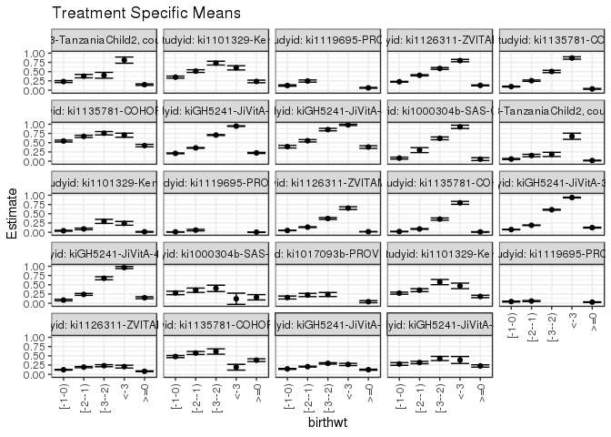

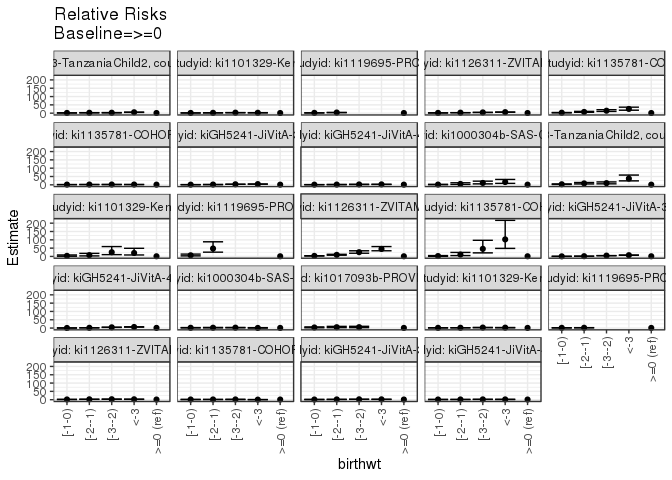

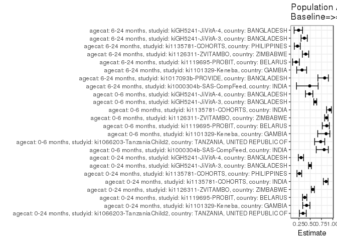

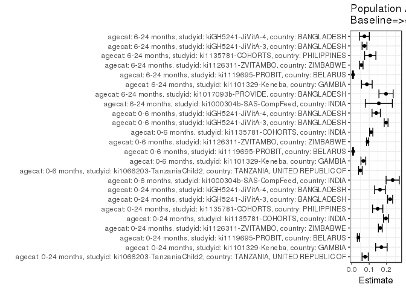

## Results Table

### Parameter: TSM

| agecat | studyid | country | intervention_level | baseline_level | estimate | ci_lower | ci_upper |
| --- | --- | --- | --- | --- | --- | --- | --- |
| 0-24 months | ki1066203-TanzaniaChild2 | TANZANIA, UNITED REPUBLIC OF | >=0 | NA | 0.1485920 | 0.1279682 | 0.1692159 |
| 0-24 months | ki1066203-TanzaniaChild2 | TANZANIA, UNITED REPUBLIC OF | <-3 | NA | 0.8115400 | 0.7273169 | 0.8957632 |
| 0-24 months | ki1066203-TanzaniaChild2 | TANZANIA, UNITED REPUBLIC OF | [-3–2) | NA | 0.4013483 | 0.3224670 | 0.4802296 |
| 0-24 months | ki1066203-TanzaniaChild2 | TANZANIA, UNITED REPUBLIC OF | [-2–1) | NA | 0.3783280 | 0.3321990 | 0.4244570 |
| 0-24 months | ki1066203-TanzaniaChild2 | TANZANIA, UNITED REPUBLIC OF | [-1-0) | NA | 0.2325646 | 0.2073961 | 0.2577331 |
| 0-24 months | ki1101329-Keneba | GAMBIA | >=0 | NA | 0.2349027 | 0.1998658 | 0.2699395 |
| 0-24 months | ki1101329-Keneba | GAMBIA | <-3 | NA | 0.6026685 | 0.5459544 | 0.6593826 |
| 0-24 months | ki1101329-Keneba | GAMBIA | [-3–2) | NA | 0.7298444 | 0.6785391 | 0.7811497 |
| 0-24 months | ki1101329-Keneba | GAMBIA | [-2–1) | NA | 0.5144162 | 0.4784374 | 0.5503950 |
| 0-24 months | ki1101329-Keneba | GAMBIA | [-1-0) | NA | 0.3508799 | 0.3225863 | 0.3791736 |
| 0-24 months | ki1119695-PROBIT | BELARUS | >=0 | NA | 0.0623956 | 0.0504473 | 0.0743440 |
| 0-24 months | ki1119695-PROBIT | BELARUS | [-2–1) | NA | 0.2459805 | 0.2165000 | 0.2754610 |
| 0-24 months | ki1119695-PROBIT | BELARUS | [-1-0) | NA | 0.1250781 | 0.1070546 | 0.1431016 |
| 0-24 months | ki1126311-ZVITAMBO | ZIMBABWE | >=0 | NA | 0.1290125 | 0.1181608 | 0.1398641 |
| 0-24 months | ki1126311-ZVITAMBO | ZIMBABWE | <-3 | NA | 0.7986901 | 0.7667858 | 0.8305944 |
| 0-24 months | ki1126311-ZVITAMBO | ZIMBABWE | [-3–2) | NA | 0.5860635 | 0.5612998 | 0.6108272 |
| 0-24 months | ki1126311-ZVITAMBO | ZIMBABWE | [-2–1) | NA | 0.4016781 | 0.3860207 | 0.4173355 |
| 0-24 months | ki1126311-ZVITAMBO | ZIMBABWE | [-1-0) | NA | 0.2265544 | 0.2160336 | 0.2370753 |
| 0-24 months | ki1135781-COHORTS | INDIA | >=0 | NA | 0.0340982 | 0.0222488 | 0.0459476 |
| 0-24 months | ki1135781-COHORTS | INDIA | <-3 | NA | 0.8689514 | 0.8369590 | 0.9009438 |
| 0-24 months | ki1135781-COHORTS | INDIA | [-3–2) | NA | 0.5045231 | 0.4737970 | 0.5352492 |
| 0-24 months | ki1135781-COHORTS | INDIA | [-2–1) | NA | 0.2553323 | 0.2379517 | 0.2727128 |
| 0-24 months | ki1135781-COHORTS | INDIA | [-1-0) | NA | 0.0964901 | 0.0852459 | 0.1077343 |
| 0-24 months | ki1135781-COHORTS | PHILIPPINES | >=0 | NA | 0.4209177 | 0.3873928 | 0.4544426 |
| 0-24 months | ki1135781-COHORTS | PHILIPPINES | <-3 | NA | 0.7023238 | 0.6477622 | 0.7568853 |
| 0-24 months | ki1135781-COHORTS | PHILIPPINES | [-3–2) | NA | 0.7556674 | 0.7106256 | 0.8007092 |
| 0-24 months | ki1135781-COHORTS | PHILIPPINES | [-2–1) | NA | 0.6704946 | 0.6396768 | 0.7013124 |
| 0-24 months | ki1135781-COHORTS | PHILIPPINES | [-1-0) | NA | 0.5449155 | 0.5198421 | 0.5699890 |
| 0-24 months | kiGH5241-JiVitA-3 | BANGLADESH | >=0 | NA | 0.2235208 | 0.2083374 | 0.2387042 |
| 0-24 months | kiGH5241-JiVitA-3 | BANGLADESH | <-3 | NA | 0.9482993 | 0.9397186 | 0.9568799 |

[output cut: 83 more lines]

### Parameter: E(Y)

| agecat | studyid | country | intervention_level | baseline_level | estimate | ci_lower | ci_upper |
| --- | --- | --- | --- | --- | --- | --- | --- |
| 0-24 months | ki1066203-TanzaniaChild2 | TANZANIA, UNITED REPUBLIC OF | NA | NA | 0.2253165 | 0.2084927 | 0.2421403 |
| 0-24 months | ki1101329-Keneba | GAMBIA | NA | NA | 0.4049080 | 0.3840027 | 0.4258132 |
| 0-24 months | ki1119695-PROBIT | BELARUS | NA | NA | 0.1006096 | 0.0848963 | 0.1163228 |
| 0-24 months | ki1126311-ZVITAMBO | ZIMBABWE | NA | NA | 0.2927003 | 0.2851706 | 0.3002300 |
| 0-24 months | ki1135781-COHORTS | INDIA | NA | NA | 0.2301329 | 0.2201057 | 0.2401602 |
| 0-24 months | ki1135781-COHORTS | PHILIPPINES | NA | NA | 0.5696245 | 0.5519304 | 0.5873185 |
| 0-24 months | kiGH5241-JiVitA-3 | BANGLADESH | NA | NA | 0.4435874 | 0.4360589 | 0.4511158 |
| 0-24 months | kiGH5241-JiVitA-4 | BANGLADESH | NA | NA | 0.5436182 | 0.5259510 | 0.5612854 |
| 0-6 months | ki1000304b-SAS-CompFeed | INDIA | NA | NA | 0.2899408 | 0.2636182 | 0.3162634 |
| 0-6 months | ki1066203-TanzaniaChild2 | TANZANIA, UNITED REPUBLIC OF | NA | NA | 0.0675105 | 0.0574070 | 0.0776141 |
| 0-6 months | ki1101329-Keneba | GAMBIA | NA | NA | 0.0779747 | 0.0661464 | 0.0898030 |
| 0-6 months | ki1119695-PROBIT | BELARUS | NA | NA | 0.0090570 | 0.0059070 | 0.0122070 |
| 0-6 months | ki1126311-ZVITAMBO | ZIMBABWE | NA | NA | 0.1050114 | 0.0999345 | 0.1100884 |
| 0-6 months | ki1135781-COHORTS | INDIA | NA | NA | 0.1191624 | 0.1113681 | 0.1269567 |
| 0-6 months | kiGH5241-JiVitA-3 | BANGLADESH | NA | NA | 0.3212848 | 0.3145332 | 0.3280365 |
| 0-6 months | kiGH5241-JiVitA-4 | BANGLADESH | NA | NA | 0.2894327 | 0.2741277 | 0.3047377 |
| 6-24 months | ki1000304b-SAS-CompFeed | INDIA | NA | NA | 0.3169456 | 0.2869579 | 0.3469333 |
| 6-24 months | ki1017093b-PROVIDE | BANGLADESH | NA | NA | 0.2394366 | 0.2018814 | 0.2769918 |
| 6-24 months | ki1101329-Keneba | GAMBIA | NA | NA | 0.2709966 | 0.2503773 | 0.2916160 |
| 6-24 months | ki1119695-PROBIT | BELARUS | NA | NA | 0.0380298 | 0.0285924 | 0.0474672 |
| 6-24 months | ki1126311-ZVITAMBO | ZIMBABWE | NA | NA | 0.1364126 | 0.1294320 | 0.1433931 |
| 6-24 months | ki1135781-COHORTS | PHILIPPINES | NA | NA | 0.4883615 | 0.4674262 | 0.5092967 |
| 6-24 months | kiGH5241-JiVitA-3 | BANGLADESH | NA | NA | 0.1974469 | 0.1893928 | 0.2055011 |
| 6-24 months | kiGH5241-JiVitA-4 | BANGLADESH | NA | NA | 0.2982358 | 0.2800848 | 0.3163868 |

### Parameter: RR

| agecat | studyid | country | intervention_level | baseline_level | estimate | ci_lower | ci_upper |
| --- | --- | --- | --- | --- | --- | --- | --- |
| 0-24 months | ki1066203-TanzaniaChild2 | TANZANIA, UNITED REPUBLIC OF | >=0 | >=0 | 1.0000000 | 1.0000000 | 1.0000000 |
| 0-24 months | ki1066203-TanzaniaChild2 | TANZANIA, UNITED REPUBLIC OF | <-3 | >=0 | 5.4615310 | 4.5932458 | 6.4939527 |
| 0-24 months | ki1066203-TanzaniaChild2 | TANZANIA, UNITED REPUBLIC OF | [-3–2) | >=0 | 2.7010082 | 2.1254034 | 3.4324992 |
| 0-24 months | ki1066203-TanzaniaChild2 | TANZANIA, UNITED REPUBLIC OF | [-2–1) | >=0 | 2.5460853 | 2.1191451 | 3.0590403 |
| 0-24 months | ki1066203-TanzaniaChild2 | TANZANIA, UNITED REPUBLIC OF | [-1-0) | >=0 | 1.5651218 | 1.3151569 | 1.8625963 |
| 0-24 months | ki1101329-Keneba | GAMBIA | >=0 | >=0 | 1.0000000 | 1.0000000 | 1.0000000 |
| 0-24 months | ki1101329-Keneba | GAMBIA | <-3 | >=0 | 2.5656095 | 2.1532343 | 3.0569605 |
| 0-24 months | ki1101329-Keneba | GAMBIA | [-3–2) | >=0 | 3.1070079 | 2.6366138 | 3.6613241 |
| 0-24 months | ki1101329-Keneba | GAMBIA | [-2–1) | >=0 | 2.1899123 | 1.8598601 | 2.5785356 |
| 0-24 months | ki1101329-Keneba | GAMBIA | [-1-0) | >=0 | 1.4937249 | 1.2634305 | 1.7659966 |
| 0-24 months | ki1119695-PROBIT | BELARUS | >=0 | >=0 | 1.0000000 | 1.0000000 | 1.0000000 |
| 0-24 months | ki1119695-PROBIT | BELARUS | [-2–1) | >=0 | 3.9422721 | 3.3746436 | 4.6053779 |
| 0-24 months | ki1119695-PROBIT | BELARUS | [-1-0) | >=0 | 2.0045979 | 1.8122503 | 2.2173607 |
| 0-24 months | ki1126311-ZVITAMBO | ZIMBABWE | >=0 | >=0 | 1.0000000 | 1.0000000 | 1.0000000 |
| 0-24 months | ki1126311-ZVITAMBO | ZIMBABWE | <-3 | >=0 | 6.1907983 | 5.6406461 | 6.7946088 |
| 0-24 months | ki1126311-ZVITAMBO | ZIMBABWE | [-3–2) | >=0 | 4.5426893 | 4.1354202 | 4.9900674 |
| 0-24 months | ki1126311-ZVITAMBO | ZIMBABWE | [-2–1) | >=0 | 3.1134832 | 2.8387950 | 3.4147509 |
| 0-24 months | ki1126311-ZVITAMBO | ZIMBABWE | [-1-0) | >=0 | 1.7560664 | 1.5958594 | 1.9323564 |
| 0-24 months | ki1135781-COHORTS | INDIA | >=0 | >=0 | 1.0000000 | 1.0000000 | 1.0000000 |
| 0-24 months | ki1135781-COHORTS | INDIA | <-3 | >=0 | 25.4838010 | 17.9680108 | 36.1433507 |
| 0-24 months | ki1135781-COHORTS | INDIA | [-3–2) | >=0 | 14.7961866 | 10.3977992 | 21.0551419 |
| 0-24 months | ki1135781-COHORTS | INDIA | [-2–1) | >=0 | 7.4881478 | 5.2556020 | 10.6690646 |
| 0-24 months | ki1135781-COHORTS | INDIA | [-1-0) | >=0 | 2.8297714 | 1.9616445 | 4.0820884 |
| 0-24 months | ki1135781-COHORTS | PHILIPPINES | >=0 | >=0 | 1.0000000 | 1.0000000 | 1.0000000 |
| 0-24 months | ki1135781-COHORTS | PHILIPPINES | <-3 | >=0 | 1.6685538 | 1.4936603 | 1.8639256 |
| 0-24 months | ki1135781-COHORTS | PHILIPPINES | [-3–2) | >=0 | 1.7952854 | 1.6265034 | 1.9815819 |
| 0-24 months | ki1135781-COHORTS | PHILIPPINES | [-2–1) | >=0 | 1.5929352 | 1.4544011 | 1.7446649 |
| 0-24 months | ki1135781-COHORTS | PHILIPPINES | [-1-0) | >=0 | 1.2945893 | 1.1822921 | 1.4175528 |
| 0-24 months | kiGH5241-JiVitA-3 | BANGLADESH | >=0 | >=0 | 1.0000000 | 1.0000000 | 1.0000000 |
| 0-24 months | kiGH5241-JiVitA-3 | BANGLADESH | <-3 | >=0 | 4.2425555 | 3.9631480 | 4.5416615 |

[output cut: 83 more lines]

### Parameter: PAR

| agecat | studyid | country | intervention_level | baseline_level | estimate | ci_lower | ci_upper |
| --- | --- | --- | --- | --- | --- | --- | --- |
| 0-24 months | ki1066203-TanzaniaChild2 | TANZANIA, UNITED REPUBLIC OF | >=0 | NA | 0.0767244 | 0.0589693 | 0.0944796 |
| 0-24 months | ki1101329-Keneba | GAMBIA | >=0 | NA | 0.1700053 | 0.1369160 | 0.2030947 |
| 0-24 months | ki1119695-PROBIT | BELARUS | >=0 | NA | 0.0382140 | 0.0316830 | 0.0447449 |
| 0-24 months | ki1126311-ZVITAMBO | ZIMBABWE | >=0 | NA | 0.1636879 | 0.1529008 | 0.1744749 |
| 0-24 months | ki1135781-COHORTS | INDIA | >=0 | NA | 0.1960348 | 0.1816858 | 0.2103837 |
| 0-24 months | ki1135781-COHORTS | PHILIPPINES | >=0 | NA | 0.1487068 | 0.1192162 | 0.1781973 |
| 0-24 months | kiGH5241-JiVitA-3 | BANGLADESH | >=0 | NA | 0.2200666 | 0.2057786 | 0.2343546 |
| 0-24 months | kiGH5241-JiVitA-4 | BANGLADESH | >=0 | NA | 0.1618534 | 0.1308321 | 0.1928747 |
| 0-6 months | ki1000304b-SAS-CompFeed | INDIA | >=0 | NA | 0.2345542 | 0.1968354 | 0.2722731 |
| 0-6 months | ki1066203-TanzaniaChild2 | TANZANIA, UNITED REPUBLIC OF | >=0 | NA | 0.0494446 | 0.0391107 | 0.0597785 |
| 0-6 months | ki1101329-Keneba | GAMBIA | >=0 | NA | 0.0664482 | 0.0526807 | 0.0802157 |
| 0-6 months | ki1119695-PROBIT | BELARUS | >=0 | NA | 0.0078444 | 0.0049667 | 0.0107222 |
| 0-6 months | ki1126311-ZVITAMBO | ZIMBABWE | >=0 | NA | 0.0905392 | 0.0847048 | 0.0963737 |
| 0-6 months | ki1135781-COHORTS | INDIA | >=0 | NA | 0.1114120 | 0.1021341 | 0.1206899 |
| 0-6 months | kiGH5241-JiVitA-3 | BANGLADESH | >=0 | NA | 0.1969546 | 0.1859597 | 0.2079495 |
| 0-6 months | kiGH5241-JiVitA-4 | BANGLADESH | >=0 | NA | 0.1400767 | 0.1161866 | 0.1639669 |
| 6-24 months | ki1000304b-SAS-CompFeed | INDIA | >=0 | NA | 0.1550934 | 0.0774881 | 0.2326988 |
| 6-24 months | ki1017093b-PROVIDE | BANGLADESH | >=0 | NA | 0.1965136 | 0.1557316 | 0.2372956 |
| 6-24 months | ki1101329-Keneba | GAMBIA | >=0 | NA | 0.0865203 | 0.0558946 | 0.1171461 |
| 6-24 months | ki1119695-PROBIT | BELARUS | >=0 | NA | 0.0071414 | 0.0040201 | 0.0102627 |
| 6-24 months | ki1126311-ZVITAMBO | ZIMBABWE | >=0 | NA | 0.0547285 | 0.0448367 | 0.0646203 |
| 6-24 months | ki1135781-COHORTS | PHILIPPINES | >=0 | NA | 0.1060552 | 0.0738673 | 0.1382430 |
| 6-24 months | kiGH5241-JiVitA-3 | BANGLADESH | >=0 | NA | 0.0730384 | 0.0591291 | 0.0869478 |
| 6-24 months | kiGH5241-JiVitA-4 | BANGLADESH | >=0 | NA | 0.0725293 | 0.0444188 | 0.1006399 |

### Parameter: PAF

| agecat | studyid | country | intervention_level | baseline_level | estimate | ci_lower | ci_upper |
| --- | --- | --- | --- | --- | --- | --- | --- |
| 0-24 months | ki1066203-TanzaniaChild2 | TANZANIA, UNITED REPUBLIC OF | >=0 | NA | 0.3405185 | 0.2605580 | 0.4118323 |
| 0-24 months | ki1101329-Keneba | GAMBIA | >=0 | NA | 0.4198616 | 0.3343076 | 0.4944203 |
| 0-24 months | ki1119695-PROBIT | BELARUS | >=0 | NA | 0.3798243 | 0.3308199 | 0.4252400 |
| 0-24 months | ki1126311-ZVITAMBO | ZIMBABWE | >=0 | NA | 0.5592336 | 0.5231295 | 0.5926042 |
| 0-24 months | ki1135781-COHORTS | INDIA | >=0 | NA | 0.8518327 | 0.7910422 | 0.8949378 |
| 0-24 months | ki1135781-COHORTS | PHILIPPINES | >=0 | NA | 0.2610611 | 0.2072420 | 0.3112265 |
| 0-24 months | kiGH5241-JiVitA-3 | BANGLADESH | >=0 | NA | 0.4961065 | 0.4629353 | 0.5272290 |
| 0-24 months | kiGH5241-JiVitA-4 | BANGLADESH | >=0 | NA | 0.2977336 | 0.2376967 | 0.3530421 |
| 0-6 months | ki1000304b-SAS-CompFeed | INDIA | >=0 | NA | 0.8089728 | 0.6332365 | 0.9005043 |
| 0-6 months | ki1066203-TanzaniaChild2 | TANZANIA, UNITED REPUBLIC OF | >=0 | NA | 0.7323983 | 0.5980038 | 0.8218623 |
| 0-6 months | ki1101329-Keneba | GAMBIA | >=0 | NA | 0.8521768 | 0.6661050 | 0.9345552 |
| 0-6 months | ki1119695-PROBIT | BELARUS | >=0 | NA | 0.8661169 | 0.7671980 | 0.9230046 |
| 0-6 months | ki1126311-ZVITAMBO | ZIMBABWE | >=0 | NA | 0.8621848 | 0.8199205 | 0.8945297 |
| 0-6 months | ki1135781-COHORTS | INDIA | >=0 | NA | 0.9349592 | 0.8629937 | 0.9691232 |
| 0-6 months | kiGH5241-JiVitA-3 | BANGLADESH | >=0 | NA | 0.6130217 | 0.5789954 | 0.6442980 |
| 0-6 months | kiGH5241-JiVitA-4 | BANGLADESH | >=0 | NA | 0.4839700 | 0.3961853 | 0.5589922 |
| 6-24 months | ki1000304b-SAS-CompFeed | INDIA | >=0 | NA | 0.4893377 | 0.1964943 | 0.6754522 |
| 6-24 months | ki1017093b-PROVIDE | BANGLADESH | >=0 | NA | 0.8207332 | 0.6703559 | 0.9025113 |
| 6-24 months | ki1101329-Keneba | GAMBIA | >=0 | NA | 0.3192672 | 0.2005236 | 0.4203741 |
| 6-24 months | ki1119695-PROBIT | BELARUS | >=0 | NA | 0.1877845 | 0.1095527 | 0.2591431 |
| 6-24 months | ki1126311-ZVITAMBO | ZIMBABWE | >=0 | NA | 0.4011985 | 0.3273908 | 0.4669069 |
| 6-24 months | ki1135781-COHORTS | PHILIPPINES | >=0 | NA | 0.2171653 | 0.1484507 | 0.2803351 |
| 6-24 months | kiGH5241-JiVitA-3 | BANGLADESH | >=0 | NA | 0.3699141 | 0.2971166 | 0.4351721 |
| 6-24 months | kiGH5241-JiVitA-4 | BANGLADESH | >=0 | NA | 0.2431946 | 0.1439952 | 0.3308981 |